# manuscript

# 2 Introduction

Maize (*Zea mays* L.) is part of the Poaceae family and was domesticated in southern Mexico approximately 9,000 years ago [(Panda et al., 2020)](https://www.zotero.org/google-docs/?BjFQmB). Maize is the third most important crop in the world, following wheat and rice [(Kaushal et al., 2023)](https://www.zotero.org/google-docs/?3dryQA). Global maize production has increased in recent decades, and maize is the leading cereal in terms of production volume [(Erenstein et al., 2022)](https://www.zotero.org/google-docs/?T9YK4N). In Peru, four types of maize are produced: yellow maize, starchy maize, green maize, and purple maize. In 2023, purple maize exports reached $2.25 million, with a price of $2.04 per kilogram (AGRODATA PERU, 2024).

Purple maize is the only grain in the world where the kernels, husks, and cobs are purple to black due to the presence of anthocyanins. It has a high anthocyanin content, and its flavonoids are water-soluble, and possess antioxidant and anti-inflammatory properties [(Rabanal-Atalaya & Medina-Hoyos, 2021)](https://www.zotero.org/google-docs/?bHtX0o). Its consumption preferences are primarily based on color, flavor, and nutritional benefits [(Chachar et al., 2024)](https://www.zotero.org/google-docs/?BFA9HY). In addition to its high content of minerals, vitamins such as ascorbic acid and B complex, proteins are present in the endosperm, and it is rich in phytochemicals such as anthocyanins, melatonin, and tryptophan [(Duangpapeng et al., 2019)](https://www.zotero.org/google-docs/?4LMRWP). It is used in the food and pharmaceutical industries as a healthier alternative to synthetic additives [(Rabanal-Atalaya & Medina-Hoyos, 2021)](https://www.zotero.org/google-docs/?5UM357).

Maize is directly sown in the field, and its productivity depends on germination and plant density [(da Silva et al., 2021)](https://www.zotero.org/google-docs/?lLAD3M). Seed germination is a critical stage in crop production that directly affects the yield and quality of maize grains [(Han et al., 2020)](https://www.zotero.org/google-docs/?OA0C6W). Therefore, good initial development of seeds with high sanitary and physiological qualities allows proper adaptability, plant vigor, and high yields [(Huang et al., 2018; Vieira et al., 2019)](https://www.zotero.org/google-docs/?mBBewB). Pre-sowing seed treatments have proven to be effective techniques for achieving early emergence, optimal field density, and a high percentage of germination [(K et al., 2020)](https://www.zotero.org/google-docs/?9McfkN). These treatments, combined with extended imbibition time, increase seed hydration and the initiation of germination [(Morales Pizarro et al., 2023)](https://www.zotero.org/google-docs/?NXgddv). During the germination process, both gibberellic acid (GA) and reactive oxygen species (ROS) act to mobilize reserve substances, break the seed coat, improve imbibition, and promote the emergence of the radicle [(Jhanji et al., 2024)](https://www.zotero.org/google-docs/?UEBZuh). Seaweed extracts of hard yellow maize seeds stimulate root growth, esterase activity, ATP formation, and nutrition [(Ertani et al., 2018)](https://www.zotero.org/google-docs/?sSPmoX). Another input used as a pre-sowing treatment is sulfur in the form of sulfur dioxide (SO₂), which promotes the production of reactive oxygen species (ROS). These ROS contribute to the induction of α-amylase activity, facilitating the release of nutrients from the endosperm and promoting the germination of maize seeds treated with SO₂ [(Guo et al., 2021)](https://www.zotero.org/google-docs/?2DGflE). Recent studies have shown that whey improves maize growth traits, including shoot height, number of leaves, shoot weight, and cob weight [(Abdelraof et al., 2023)](https://www.zotero.org/google-docs/?YTR5bF).

The objectives of this research were: (a) to evaluate the germination parameters of a hybrid variety compared with those of a native strain of purple maize seeds via organic biostimulants, and (b) to identify the best organic biostimulant that positively influences the growth and development of purple maize producing seedlings.

# 3 Materials and methods

## 3.1 Study location

The study was conducted in the greenhouse of the Department of Plant Morphophysiology at the Faculty of Agronomy, National University of Piura, Peru, located at 5°10’33” S and 80°37’17” W (Figure 1), at an altitude of 30 m above sea level, from December 2022 to February 2023.

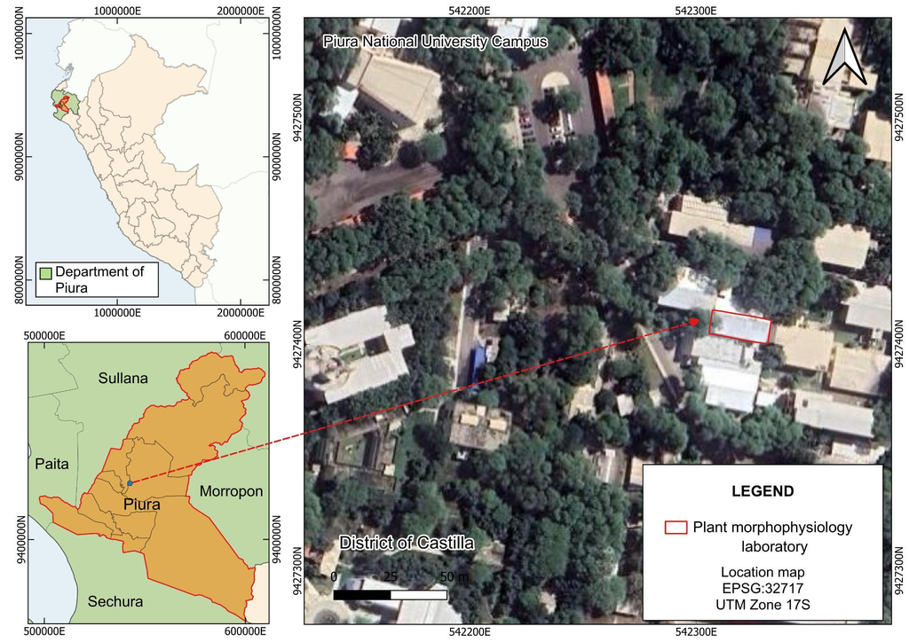

Figure 1: Geographical location of the laboratory to evaluate the effect of stimulants in the germination and initial biometrics of two varieties of purple maize (*Zea mays* L.) conducted in the Piura Region.

## 3.2 Plant material and stimulants

In this study, two purple maize varieties, the native and the hybrid PMV 581, were used. The native variety was obtained from purple maize cobs harvested in August 2022, in the Santa Elena sector of Pueblo Nuevo de Colán, Paita district located at 5°5’21.01” S, 81°6’51.98” W, at an altitude of 3 m above sea level. The best cobs with the most favorable morphological characteristics, including shape, large size, and freedom from diseases and abnormalities were selected. The seeds were subsequently separated, washed, and placed on previously flamed paper towels for drying for 12 hours at room temperature (27±3 °C). The seeds were disinfected with 76% alcohol for 5 seconds and then dried at room temperature.

The hybrid variety is derived from the Morado de Caraz variety [(Medina-Hoyos et al., 2020a)](https://www.zotero.org/google-docs/?1Bt6b0). It was developed by professionals from the Maize Program at the Universidad Nacional Agraria, La Molina. It is adapted to the coastal and lowland regions of Peru and is resistant to certain pests and diseases common in purple maize cultivation. It is characterized by a yield of 6 t/ha with an intermediate vegetative period, and medium-sized cobs ranging from 15 to 20 cm, with a high pigment content.

Two organic products and one inorganic product were used. Seaweed ‘Algaeforte’ (Aris industrial, Peru), dry sulfur powder 930 g/kg (Aris industrial, Peru), and mil whey were obtained from cheese production. For this purpose, a vegetable rennet tablet was added to the milk at a temperature of 37 °C; the liquid suspended at the top was considered whey [(Sousa & Malcata, 1998)](https://www.zotero.org/google-docs/?O9GlRE).

## 3.3 Seed characterization and presowing treatments

Seed characterization was carried out in the Plant Morphophysiology Laboratory of the Faculty of Agronomy. The dimensions, length, width, thickness (mm), and weight (g) of 150 seeds from each species under study were evaluated. The seed shape was determined based on its length/width ratio: flat seed (<1), round seed (=1), and oval seed (>1), according to the description by Ruesta-López et al. [(Ruesta-López et al., 2024)](https://www.zotero.org/google-docs/?cYbUnP)

**Table 1:** Pre-sowing treatments used on purple maize seeds (*Zea mays* L.) from the native variety and Hybrid PMV 581 to evaluate their influence on germination and early development. Seeds were immersed in the seeds treatment solutions for 12 hours. |

| **Number** | **Description** | **Dose** |
| --- | --- | --- |
| T0 | distilled water | 100% |
| T1 | seaweed | 1 L/200 L |
| T2 | seaweed | 1.5 L/200 L |
| T3 | sulfur | 100 gr/200 L |
| T4 | sulfur | 150 gr/200 L |
| T5 | milk whey | 10% 10 mL/90 mL |
| T6 | milk whey | 30% 30 mL/70 mL |

## 3.4 Seed germination experiment

The germination experiment was conducted using a completely randomized design (CRD) to evaluate the effect of sowing treatments on the germination of two purple maize varieties. Three replications were established for each treatment. Each replication consists of 25 seeds. Germination was assessed daily over five (5) days at 27±3 °C until the radicle emergence as the criterion for germination [(Lozano-Isla et al., 2019)](https://www.zotero.org/google-docs/?l57MRP).

The traits assessed during the seed germination were carried out under aseptic conditions in the laboratory, according to Morales Pizarro et al., [(Morales Pizarro et al., 2023)](https://www.zotero.org/google-docs/?9NtOdd). The seed imbibition rate (IR) was evaluated during the pre-sowing treatment. Additionally, three germination indices were evaluated, germination percentage (GP), germination velocity (GV), and germination index (GI).

*Imbibition rate* **(IR, %):** It was expressed according to the formula by Escobar-Álvarez et al., [(Escobar-Álvarez et al., 2021)](https://www.zotero.org/google-docs/?nGSNWt) which relates the percentage increase in seed weight (absorption or hydration of water) to the initial and final weight of the seed [(Ruesta-López et al., 2024)](https://www.zotero.org/google-docs/?4OStxn).

**Germination percentage** **(GP, %):** GP was calculated using the following formula [(Escobar-Álvarez et al., 2021)](https://www.zotero.org/google-docs/?UxvsxB): $GP\ \left(\%\right)\ =\ \left(\frac{Total\ number\ of\ seeds\ germinated}{Total\ number\ of\ seed}\right)\cdot100$ .

**Germination speed** **(GS, days):** GV was determined using the formula proposed by Gutiérrez-Gutiérrez et al., [(Gutiérrez-Gutiérrez et al., 2022)](https://www.zotero.org/google-docs/?cWwtrJ) : $GV\ =\ \left(\frac{Number\ of\ seeds\ germinated\ on\ the\ n-th\ day}{Number\ of\ days\ since\ the\ start\ of\ the\ experiment}\right)$

*Germination index* **(GI):** GI was calculated using the formula proposed by Scott et al. [(Scott et al., 1984)](https://www.zotero.org/google-docs/?2jk6sl): $GI\ =\ \left(\frac{\left(Number\ of\ days\ since\ the\ start\ of\ germination\right)\times(Number\ of\ seeds\ germinated)}{Total\ number\ of\ seeds}\right)$

## 3.5 Early development stage

In the greenhouse stage, a completely randomized design (CRD) with 3 replications was used, with each replication consisting of 30 seedlings per treatment. The seeds treated with the different stimulants (Table 1) were sown in germination trays measuring 54.5 x 28 cm, with a total of 72 cells, each with a capacity of 5 cc, containing sterile substrate at a 2:1 ratio (humus: river sand). Each cell was sown with 2 seeds and after emergence, only one seedling per cell was maintained.

Fifteen days after emergence (DAE), 15 plants were randomly selected per treatment. Eleven traits were evaluated, root length (RL, cm), root thickness (RT, mm), number of roots (NR), plant height (PH, cm), stem thickness (ST, mm), leaf length (LL, cm), leaf width (LW, cm), number of leaves (NL), dry root weight (DRW, g) and dry stem weight (DSW, g).

## 3.6 Statistical analysis

Statistical R software version 4.4.1 was used for the data analysis and graphics (R Core Team 4.4.1, Supplementary Material 2, [(R Core Team, 2024)](https://www.zotero.org/google-docs/?H0MnW4)). Analysis of variance was performed to determine if there were differences between the stimulant treatments. The mean comparison test used was Tukey’s test, implemented in the *emmeans* package [(Lenth et al., 2024)](https://www.zotero.org/google-docs/?EO7zMK). The traits under study were subjected to multivariate principal component analysis (PCA) via the *FactoMineR* package. Correlation analysis between the variables was performed via the corrplot package [(Husson et al., 2024)](https://www.zotero.org/google-docs/?Po8Ah4) .

# 4 Results

## 4.1 Seed characterization and germinability

To standardize the evaluations for determining the imbibition process and germination, both native and hybrid purple maize seeds were characterized (Table 2).

**Table 2:** Seed characterization of two varieties of purple maize (*Zea mays* L.). A total of 150 seeds per variety were evaluated, determining the following parameters: length (L, mm), width (W, mm), length/width ratio, thickness (mm), and weight (g). Mean comparison tests using Tukey were employed to compare the means between varieties. Distinct letters in the same row indicate significant differences (p ≤ 0.05) between the varieties for each characteristic. |

| **Variety** | **Seed Length (mm)** | **Seed Width (mm)** | **Length/Width** | **Seed Thickness (mm)** | **Seed Weight (g)** |
| --- | --- | --- | --- | --- | --- |
| Creole | 14.76±0.09 a | 10.69±0.07 b | 1.39±0.01 a | 5.5±0.09 b | 0.46±0.01 b |
| Hybrid | 14.77±0.09 a | 12.6±0.07 a | 1.17±0.01 b | 6.13±0.09 a | 0.64±0.01 a |

**Seed imbibition and germination**

To promote vigorous seed germination and improve the productivity of native and hybrid PMV 581 purple maize. Germination tests were conducted under controlled laboratory conditions. The effects of different stimulants on germination variables were evaluated to determine whether there were significant differences in germination capacity between the two varieties and to identify the most effective stimulants for improving germination parameters.

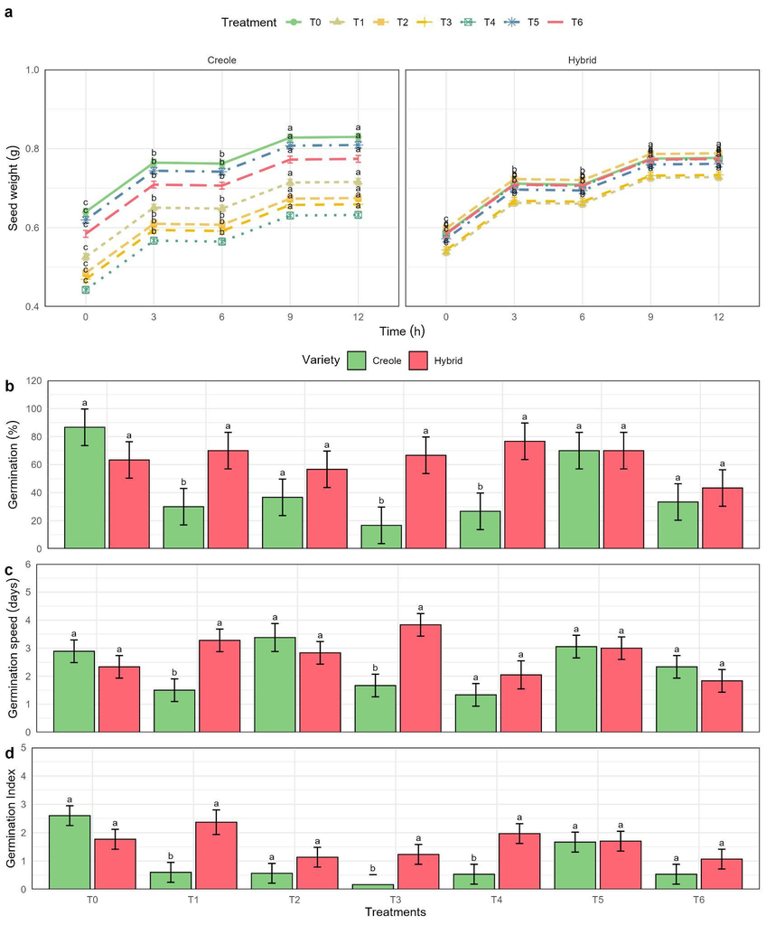

Figure 2: Seed imbibition and germination indices evaluated under use of stimulants in two purple maize varieties. (a) Imbibition of native purple maize and hybrid PMV 581 seeds (b) Germination percentage (GP), (c) Germination speed (GS), (d) Germination index (GI). Different letters represent significant differences in the Tukey post hoc test (p < 0.05).

**Effects of biostimulants in the greenhouse**

To evaluate the effects of different stimulants on the growth and initial development of purple maize seedlings, biometric characteristics were assessed 15 days after germination. Treatments with different concentrations of stimulants were compared to a control group (T0, Figure 3).

On the other hand, for the root thickness variable, significant differences were found between the treatments and varieties (p-value < 0.001). For the native variety, the highest mean was found with the control treatment at 1.25 mm, followed by the treatment with 10% milk whey 10 mL/90 mL with 1.10 mm. However, the lowest mean was recorded in the treatment with 1 L/200 L seaweed, with a value of 0.74 mm. On the other hand, in the hybrid variety, the highest mean was recorded in the control treatment at 1.08 mm, whereas the lowest mean was observed in the treatment with sulfur 100 g/200 L sulfur at 0.77 mm (Figure 3b).

In terms of the number of roots, significant differences were observed between the treatments and varieties (p-value < 0.001). For creole variety, the greatest mean number of roots was observed in the treatment with 1.5 L/200 L seaweed at 15.06 whereas the lowest mean was recorded in the control treatment at 10.86. For the hybrid variety, the highest mean number of roots was obtained with the T1 treatment at 15.73, whereas the lowest mean was recorded with the 30% milk whey treatment (30 mL/70 mL) at 10.26. These findings suggest that the application of seaweed to both varieties stimulated greater root formation (Figure 3c).

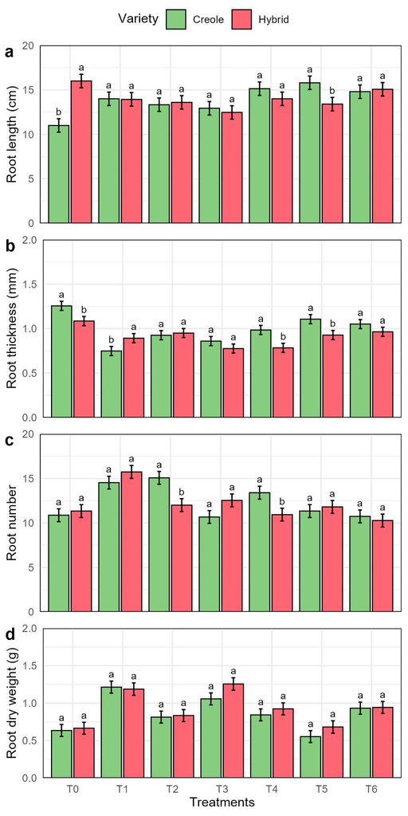

Figure 3: Roots traits of two purple maize varieties, creole and hybrid PMV 581. The analysis is based on fifteen plants per treatment (n = 105). Where (a) root length (cm), (b) root thickness (mm), (c) number of roots, (d) dry root weight (g). Different letters represent significant differences in Tukey’s multiple comparison tests (p < 0.05).

Statistical analysis via Tukey’s post hoc test (α = 0.05) revealed significant differences in plant height based on the interaction between treatments and varieties (p-value < 0.001). Significant differences were observed between the combinations of each treatment and the varieties, except for the treatments with 100 g/200 L sulfur and 10% milk whey (10 mL/90 mL), where similar effects were noted. When the creole variety was combined with distilled water (30.80 cm) and 150 g/200 L sulfur (40.53 cm), the average plant height was greater than that of the hybrid. In contrast, the hybrid variety, when combined with the 1 L/200 L seaweed, 1.5 L/200 L seaweed, and 30% milk whey (30 mL/70 mL), with heights of 46.33 cm, 44.20 cm, and 28.80 cm respectively, achieved greater average plant heights than did the creole variety. Additionally, the creole variety, with the application of seaweed and sulfur at both doses, presented relatively high average plant heights of 40.20 cm and 40.50 cm, respectively. In contrast, the application of milk whey at both doses resulted in lower values of 24.60 cm, and the control with distilled water had an average height of 30.80 cm. Similarly, for the hybrid variety, the highest average plant heights were achieved with the application of seaweed and sulfur, measuring 46.30 cm and 37.07 cm, respectively. The lowest values were observed with the application of milk whey, at 28.80 cm, and distilled water, at 26.13 cm (Table 3).

For stem thickness, significant differences were also found between the interactions of treatments and varieties (p-value < 0.01). Significant differences were observed between the combinations of the varieties with distilled water, 100 g/200 L sulfur, and 150 g/200 L sulfur, where the creole variety presented higher average values than did the hybrid with stem thicknesses of 4.47 mm, 4.51 mm, and 4.32 mm of stem thickness, respectively. Additionally, the creole variety presented higher averages with the application of seaweed at both doses, reaching 5.03 mm; conversely, the lowest values were observed with the application of milk whey, which had an average of 4.1 mm. For the hybrid variety, the highest averages were also observed with the application of seaweed, with an average of 5.38 mm, in contrast to the application of distilled water and 150 g/200 L sulfur, where the lowest averages were recorded at 3.89 mm and 3.70 mm, respectively. Compared with the hybrid with a 30.2 mm stem thickness, the creole varieties presented, on average, greater values of 31.48 mm (Table 3).

Table 3: Early development evaluation of purple maize seedlings in two purple maize varieties. Plant height, stem thickness, number of leaves, leaf length, leaf thickness, leaf width, and shoot dry weight. Calculations were based on fifteen seedlings assessed per treatment in two varieties (n = 105). Different letters indicate significant differences as determined by Tukey’s test at a 95% confidence level. |

| **Variety** | **Treatment** | **Plant height (cm)** | **Stem thickness (mm)** | **Leaves number** | **Leaf length (cm)** | **Leaf thickness (mm)** | **Leaf width (mm)** | **Shoot Dry weight (g)** |
| --- | --- | --- | --- | --- | --- | --- | --- | --- |
| Creole | T0 | 30.8 a | 4.47 a | 5.01 a | 26.2 a | 0.97 a | 18.87 a | 0.71 a |
| Hybrid | T0 | 26.13 b | 3.89 b | 4.67 b | 22.67 b | 0.88 a | 16.61 b | 0.43 a |
| Creole | T1 | 40.27 b | 4.85 a | 5.53 a | 28.33 b | 0.63 b | 18.96 a | 1.5 b |
| Hybrid | T1 | 46.33 a | 4.92 a | 5.47 a | 36.27 a | 0.84 a | 20.04 a | 2.03 a |
| Creole | T2 | 39.4 b | 5.03 a | 5.53 a | 34.8 a | 0.7 a | 19.03 b | 1.09 a |
| Hybrid | T2 | 44.2 a | 5.38 a | 5.53 a | 33.87 a | 0.76 a | 21.77 a | 1.21 a |
| Creole | T3 | 38.27 a | 4.51 a | 4.99 a | 28.6 a | 0.63 a | 19.05 a | 1.72 a |
| Hybrid | T3 | 37.07 a | 4.02 b | 5.01 a | 28.93 a | 0.69 a | 17.52 a | 1.41 b |
| Creole | T4 | 40.53 a | 4.32 a | 5.15 a | 28.27 a | 0.69 a | 17.07 a | 1.19 a |
| Hybrid | T4 | 33.07 b | 3.7 b | 5.01 a | 23.33 b | 0.64 a | 16.07 a | 1.1 a |
| Creole | T5 | 27.53 a | 4.2 a | 5 a | 23.4 b | 0.94 a | 18.29 a | 0.65 a |
| Hybrid | T5 | 30.27 a | 4.07 a | 5.01 a | 26.47 a | 0.81 b | 19.52 a | 0.64 a |
| Creole | T6 | 24.67 b | 4.1 a | 5 a | 21.53 a | 0.81 a | 17.55 a | 0.55 a |
| Hybrid | T6 | 28.8 a | 4.22 a | 5 a | 23.07 a | 0.72 a | 17.86 a | 0.46 a |

For the hybrid variety, the highest average length was also observed with the application of seaweed, with an average leaf length of 36.20 cm. In contrast, the lowest averages were observed with the application of distilled water, with a leaf length of 22.60 cm (Table 3).

Finally, for shoot dry weight, significant differences were also observed between the interaction of treatment and variety (p-value < 0.01). Significant differences were observed between the combinations of varieties subjected to the 1 L/200 L seaweed treatment, where the hybrid variety presented a relatively high average yield of 2.03 g, and the 100 g/200 L, sulfur treatment where the creole variety presented a relatively high average yield of 1.72 g of shoot dry weight. Similarly, these treatments presented the highest averages within each variety (Table 3).

To evaluate the interaction of the variables, a multivariate principal component analysis (PCA) method was used (Figure 4). The first two components explain 52.62% of the variance for dimension 1 and 22.93% for dimension 2, accounting for a cumulative variance of 75.55% (Figure 4a, Supplementary Figure 1a). For dimension 1, the variables shoot dry weight (15.38%), leaf length (15.41%), and plant height (17.35%) contributed the most to this dimension, whereas root length (2.82%) and leaf thickness (5.00%) made the smallest contributions (Figure 4, Supplementary Figure 1b). In dimension 2, leaf width (19.31%), root thickness (21.21%), and leaf thickness (22.60%) had the greatest contributions, whereas root number (0.47%), shoot dry weight (1.22%), and root length (2.34%) had the smallest contributions to this dimension (Figure 4a, Supplementary Figure 1c).

On the other hand, the combination of T0-creole aligns with the vectors for leaf thickness and root thickness. Therefore, individuals subjected to these treatments presented higher values for these variables. In terms of root length, the combinations T0-hybrid, T6-creole, and T6-hybrid presented the greatest values. Additionally, for the variables leaf width, leaf length, stem thickness, number of roots, and plant height, the combinations T1-hybrid, T2-creole, and T2-hybrid presented the highest values. For the variables shoot dry weight and root dry weight, the combinations of T1-creole, T3-creole, and T3-hybrid presented the highest values (Figure 4b).

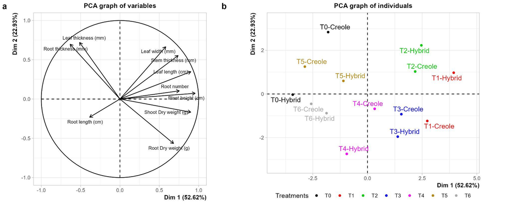

# 5 Discussion

Corn is a crop that has excellent nutritional properties and health benefits [7]. However, the effective production of purple corn can be affected by factors related to seed germination. The use of stimulants before planting has emerged as a technique to improve planting outcomes. In the present study, the effects of different stimulants on the germination of purple corn seeds from two varieties were investigated. We evaluated how these stimulants influence the germination and initial development of purple corn seedlings, with the aim of optimizing cultivation conditions and ensuring greater production efficiency.

The germination index (IG) is a parameter that results from the germination time (TI) as it reflects the ability of a seed to germinate and emerge uniformly within a given period. The results obtained in this study indicate that for the creole variety, the T0 treatment had the highest IG of 2.6, followed by the T5 treatment of 1.67, although no significant differences were observed between the two treatments. Other authors, such as Escobar-Álvarez et al. [(Escobar-Álvarez et al., 2021)](https://www.zotero.org/google-docs/?rlsaKC), mention that this can be attributed to the thickness of the seed coat in *Zea spp*. varieties, which varies between 98.9% and 100%, with the IG occurring between 1.43 and 1.53 days.

For early development, the use of seaweed-based stimulants had significant positive effects on both the creole purple corn variety and the improved hybrid variety (Figure 3). The application of seaweed extract as a stimulant is important in the agronomic management of crops and promotes organic agriculture [(Mamede et al., 2024)](https://www.zotero.org/google-docs/?tCrbGM). Compared with the control plants, the seaweed-treated plants presented significant differences in terms of root length, thickness, and number, along with significant increases in stem and leaf biomass (Figure 3 y Figure 4). Similar results were reported by Fatriana et al. [(Fatriana et al., 2020)](https://www.zotero.org/google-docs/?6HSmvU), who evaluated the application of seaweed stimulants at three concentrations (30%, 60%, and 90%) to corn plants (*Zea mays* L). They reported significant differences in stem and leaf biomass, as well as in-ear weight, length, and diameter. In the study by Shukla & Prithiviraj [(Shukla & Prithiviraj, 2021)](https://www.zotero.org/google-docs/?Vdbnp0), seaweed extract was applied as a stimulant in maize cultivation in phosphorus (P) deficient soils. These authors reported a significant difference in shoot and root biomass in the treated plants. Our results revealed that the application of seaweed extract had a significant effect on both the root biomass (length, thickness, and quantity) and the leaves and stems of the plant (Figure 3). Similar results were reported by Ertani et al. [(Ertani et al., 2018)](https://www.zotero.org/google-docs/?dWsAJ1), who evaluated five seaweed extracts (*Ascophyllum nodosum*) from maize plants. In the experiment, they were supplied with a concentration of 0.5 ml/L for two days. We applied two doses of seaweed extract, 1 liter and 1.5 liter per 200 liter. We observed a significant effect in both cases on plant growth and root biomass in both creole corn and improved hybrid corn (Figure 3). Similarly, Gandhi et al. [(Gandhi et al., 2024)](https://www.zotero.org/google-docs/?GD8ROa) evaluated extracts from two cultivable red algae, *Kappaphycus alvarezii* (KAE), *Gracilaria debilis* (GDE), and *Sargassum cinctum* (SCE) in *Zea mays*. The field study lasted for two years, during which they evaluated growth parameters, yield, and grain quality. The study applied doses ranging from 2.5% to 15%. The results revealed significant increases in yields of 19%, 21%, and 20% respectively. Additionally, the study indicated that the most effective dose was 7.5%, as no further improvement was observed beyond this dosage point. The two doses of seaweed applied in our experiment had a significant effect on plant growth and root biomass in creole and hybrid maize.

In the case of inorganic stimulants the use of sulfur in the development of seedlings for both the creole purple maize and hybrid varieties had positive effects at both applied doses (Figure 3, Table 3). This compound plays a crucial role in plant growth and development, as it acts as a structural component of macromolecules and modulates various physiological processes. Additionally, it can function as a key molecule that stimulates root growth and elongation [(Guo et al., 2021; Zenda et al., 2021)](https://www.zotero.org/google-docs/?0bk9Fp). The results obtained in this study revealed that seedlings treated with this stimulant presented increases in root length and dry weight (Figure 3); similarly, the greatest increases in the aerial part were observed in the height and dry weight of the seedlings (Table 3), with those in the control treatment. Pourbabaee et al. [(Pourbabaee et al., 2020)](https://www.zotero.org/google-docs/?pS3sAv) obtained similar results when different doses of sulfur were applied to maize seedlings, which resulted in significant increases in stem diameter, plant height, and shoot weight. On their part. Riffat and Ahmad [(Riffat & Ahmad, 2020)](https://www.zotero.org/google-docs/?9gsQln) reported significant improvements in growth parameters, including root and shoot length and dry weight of maize seedlings, in their experiment with two doses of sulfur. The authors attributed these benefits to the ability of sulfur to increase photosynthesis, photosynthesis attributes, and the concentration of biomolecules that support plant growth and development. In line with the authors, it is presumed that in the present study, the application of sulfur was crucial in stimulating physiological processes such as photosynthesis, enzyme activation, protein and amino acid production, and metabolic reactions necessary for the growth and development of the seedlings [(Narayan et al., 2023)](https://www.zotero.org/google-docs/?dpOYbq)

Despite these promising findings, this study has several limitations that warrant consideration in future research. First, the sample size for the germination trials was limited because of limited access to plant material from the selected varieties. Although the study provided initial insights, increasing the number of replicates would increase the statistical power, reducing experimental error and providing more robust conclusions. Moreover, the study focused primarily on germination and early seedling development, without assessing the long-term effects of the stimulants on key agronomic variables such as yield, grain quality, and overall crop performance. Future investigations should extend beyond the initial growth stages to encompass the entire crop cycle, allowing for a comprehensive evaluation of the impact of seaweed and sulfur treatments.

Our findings indicate a promising avenue for using seaweed and sulfur as biostimulants in maize cultivation, particularly for enhancing the germination of purple corn seeds. However, further research is essential to confirm the broader applicability of these stimulants across different maize varieties and agroecosystems. In addition, future studies should consider evaluating other seed quality parameters, such as vigor, seedling uniformity, and stress tolerance, to provide a more holistic understanding of the benefits and limitations of these treatments. Addressing these gaps will be crucial for developing effective and sustainable biostimulant strategies in maize agriculture.

C**ONCLUSIONS**

# 6 References

[Abdelraof, E., Nassar, I. N., Gomaa, I., & Aboukila, E. (2023). Valorization of Cheese Whey as A Fertilizer: Effects on Maize Germination and Growth in Clay Loam and Calcareous Soil. *Egyptian Journal of Soil Science*, *63*(4), 489-502. https://doi.org/10.21608/ejss.2023.222087.1620](https://www.zotero.org/google-docs/?vR7iG5)

[Akay, A., & Sert, D. (2020). The effects of whey application on the soil biological properties and plant growth. *EURASIAN JOURNAL OF SOIL SCIENCE (EJSS)*, *9*(4), 349-355. https://doi.org/10.18393/ejss.785380](https://www.zotero.org/google-docs/?vR7iG5)

[Ali, O., Ramsubhag, A., & Jayaraman, J. (2021). Biostimulant Properties of Seaweed Extracts in Plants: Implications towards Sustainable Crop Production. *Plants*, *10*(3), 531. https://doi.org/10.3390/plants10030531](https://www.zotero.org/google-docs/?vR7iG5)

[Carrillo-Martínez, E. J., Santana-Bejarano, M. B., Zañudo-Hernández, J., & Hernández-Herrera, R. M. (2018). Imbibición de semillas de frijol mungo (Vigna radiata) en extractos del alga marina (Ulva lactuca) y su efecto de la sobre el crecimiento de las plántulas. *e-CUCBA*, *9*, Article 9. https://doi.org/10.32870/e-cucba.v0i9.102](https://www.zotero.org/google-docs/?vR7iG5)

[Chachar, Z., Lai, R., Ahmed, N., Lingling, M., Chachar, S., Paker, N. P., & Qi, Y. (2024). Cloned genes and genetic regulation of anthocyanin biosynthesis in maize, a comparative review. *Frontiers in Plant Science*, *15*. https://doi.org/10.3389/fpls.2024.1310634](https://www.zotero.org/google-docs/?vR7iG5)

[da Silva, E. E., Baio, F. H. R., Kolling, D. F., Júnior, R. S., Zanin, A. R. A., Neves, D. C., Fontoura, J. V. P. F., & Teodoro, P. E. (2021). Variable-rate in corn sowing for maximizing grain yield. *Scientific Reports*, *11*(1), 12711. https://doi.org/10.1038/s41598-021-92238-4](https://www.zotero.org/google-docs/?vR7iG5)

[Duangpapeng, P., Lertrat, K., Lomthaisong, K., Scott, M., & Suriharn, K. (2019). Variability in Anthocyanins, Phenolic Compounds and Antioxidant Capacity in the Tassels of Collected Waxy Corn Germplasm. *Agronomy*, *9*. https://doi.org/10.3390/agronomy9030158](https://www.zotero.org/google-docs/?vR7iG5)

[Erenstein, O., Jaleta, M., Sonder, K., Mottaleb, K., & Prasanna, B. M. (2022). Global maize production, consumption and trade: Trends and R&D implications. *Food Security*, *14*(5), 1295-1319. https://doi.org/10.1007/s12571-022-01288-7](https://www.zotero.org/google-docs/?vR7iG5)

[Ertani, A., Francioso, O., Tinti, A., Schiavon, M., Pizzeghello, D., & Nardi, S. (2018). Evaluation of Seaweed Extracts From Laminaria and Ascophyllum nodosum spp. As Biostimulants in Zea mays L. Using a Combination of Chemical, Biochemical and Morphological Approaches. *Frontiers in Plant Science*, *9*. https://doi.org/10.3389/fpls.2018.00428](https://www.zotero.org/google-docs/?vR7iG5)

[Escobar-Álvarez, J. L., Ramírez-Reynoso, O., Saguilán, P. C., Gutiérrez-Dorado, R., Maldonado-Peralta, M. de los Á., & Valenzuela -Lagarda, J. L. (2021). Viabilidad y germinación en semillas de maíz criollo del estado de Guerrero. *Ecosistemas y Recursos Agropecuarios*, *8*(II), Article II. https://doi.org/10.19136/era.a8nII.2963](https://www.zotero.org/google-docs/?vR7iG5)

[Fatriana, Caronge, M. W., Djawad, Y. A., Bourgougnon, N., Makkulawu, A. T., & Jumadi, O. (2020). Effect of application of algae sargassum sp. Extract to corn plants (Zea mays L.) and microbial response. *IOP Conference Series: Earth and Environmental Science*, *484*(1), 012058. https://doi.org/10.1088/1755-1315/484/1/012058](https://www.zotero.org/google-docs/?vR7iG5)

[Gandhi, G., Gopalakrishnan, V. A. K., Veeragurunathan, V., & Ghosh, A. (2024). Unlocking the potential of tropical red and brown seaweed-based biostimulants—A comparative assessment for sustainable maize (Zea mays) production. *Journal of Applied Phycology*, *36*(3), 1513-1531. https://doi.org/10.1007/s10811-023-03155-0](https://www.zotero.org/google-docs/?vR7iG5)

[Guo, Z., Zhao, J., Wang, M., Song, S., & Xia, Z. (2021). Sulfur dioxide promotes seed germination by modulating reactive oxygen species production in maize. *Plant Science*, *312*, 111027. https://doi.org/10.1016/j.plantsci.2021.111027](https://www.zotero.org/google-docs/?vR7iG5)

[Gutiérrez-Gutiérrez, O. G., Rivero-Hernández, O., Vega-Mares, J. H., & Melgoza-Castillo, A. (2022). Patrones de germinación en gramíneas presentes en el Desierto Chihuahuense. *Botanical Sciences*, *100*(4), Article 4. https://doi.org/10.17129/botsci.3007](https://www.zotero.org/google-docs/?vR7iG5)

[Han, Z., Wang, B., Tian, L., Wang, S., Zhang, J., Guo, S., Zhang, H., Xu, L., & Chen, Y. (2020). Comprehensive dynamic transcriptome analysis at two seed germination stages in maize (Zea mays L.). *Physiologia Plantarum*, *168*(1), 205-217. https://doi.org/10.1111/ppl.12944](https://www.zotero.org/google-docs/?vR7iG5)

[Hernández-Herrera, R. M., González-González, M. F., Velasco-Ramírez, A. P., Velasco-Ramírez, S. F., Santacruz-Ruvalcaba, F., & Zamora-Natera, J. F. (2023). Seaweed Extract Components Are Correlated with the Seeds Germination and Growth of Tomato Seedlings. *Seeds*, *2*(4), Article 4. https://doi.org/10.3390/seeds2040033](https://www.zotero.org/google-docs/?vR7iG5)

[Huang, Y., Zhang, Y., Gao, C., Li, Z., Guan, Y., Hu, W., & Hu, J. (2018). The interactions of plant growth regulators and H2O2 during germination improvement of sweet corn seed through spermidine application. *Plant Growth Regulation*, *85*(1), 15-26. https://doi.org/10.1007/s10725-018-0370-z](https://www.zotero.org/google-docs/?vR7iG5)

[Husson, F., Josse, J., Le, S., & Mazet, J. (2024). *FactoMineR: Multivariate Exploratory Data Analysis and Data Mining*. https://doi.org/10.32614/CRAN.package.FactoMineR](https://www.zotero.org/google-docs/?vR7iG5)

[Jhanji, S., Goyal, E., Chumber, M., & Kaur, G. (2024). Exploring fine tuning between phytohormones and ROS signaling cascade in regulation of seed dormancy, germination and seedling development. *Plant Physiology and Biochemistry*, *207*, 108352. https://doi.org/10.1016/j.plaphy.2024.108352](https://www.zotero.org/google-docs/?vR7iG5)

[K, A., S, S., & K, R. (2020). Effect of Pre-germination Technique on Enhancing Seed and Seedling Vigour in Ridge gourd (LuffaacutanglaRoxb.). *Madras Agricultural Journal*, *107*(4-6). https://doi.org/10.29321/MAJ.2020.000355](https://www.zotero.org/google-docs/?vR7iG5)

[Kaushal, M., Sharma, R., Vaidya, D., Gupta, A., Saini, H. K., Anand, A., Thakur, C., Verma, A., Thakur, M., Priyanka, & KC, D. (2023). Maize: An underexploited golden cereal crop. *Cereal Research Communications*, *51*(1), 3-14. https://doi.org/10.1007/s42976-022-00280-3](https://www.zotero.org/google-docs/?vR7iG5)

[Lenth, R. V., Bolker, B., Buerkner, P., Giné-Vázquez, I., Herve, M., Jung, M., Love, J., Miguez, F., Piaskowski, J., Riebl, H., & Singmann, H. (2024). *emmeans: Estimated Marginal Means, aka Least-Squares Means* (Versión 1.10.4) [Software]. https://cran.r-project.org/web/packages/emmeans/index.html](https://www.zotero.org/google-docs/?vR7iG5)

[Lozano-Isla, F., Benites-Alfaro, O. E., & Pompelli, M. F. (2019). GerminaR: An R package for germination analysis with the interactive web application “GerminaQuant for R”. *Ecological Research*, *34*(2), 339-346. https://doi.org/10.1111/1440-1703.1275](https://www.zotero.org/google-docs/?vR7iG5)

[Mamede, M., Cotas, J., Pereira, L., & Bahcevandziev, K. (2024). Seaweed Polysaccharides as Potential Biostimulants in Turnip Greens Production. *Horticulturae*, *10*(2), Article 2. https://doi.org/10.3390/horticulturae10020130](https://www.zotero.org/google-docs/?vR7iG5)

[Medina-Hoyos, A., Narro-León, L., & Chávez-Cabrera, A. (2020a). Cultivo de maíz morado (Zea mays L.) en zona altoandina de Perú: Adaptación e identificación de cultivares de alto rendimiento y contenido de antocianina. *Scientia Agropecuaria*, *11*(3), 291-299. https://doi.org/10.17268/sci.agropecu.2020.03.01](https://www.zotero.org/google-docs/?vR7iG5)

[Medina-Hoyos, A., Narro-León, L., & Chávez-Cabrera, A. (2020b). Cultivo de maíz morado (Zea mays L.) en zona altoandina de Perú: Adaptación e identificación de cultivares de alto rendimiento y contenido de antocianina. *Scientia Agropecuaria*, *11*(3), 291-299. https://doi.org/10.17268/sci.agropecu.2020.03.01](https://www.zotero.org/google-docs/?vR7iG5)

[Morales Pizarro, A., RivasChero, A. A., Zapata Córdova, A. C., García Guevara, E., Ruesta López, M., Peña-Castillo, R., Morales Pizarro, A., RivasChero, A. A., Zapata Córdova, A. C., García Guevara, E., Ruesta López, M., & Peña-Castillo, R. (2023). EFECTO DE DIFERENTES DOSIS DE ÁCIDO GIBERÉLICO EN LA GERMINACIÓN DE PAPAYA (Carica papaya L.) VARIEDAD CRIOLLA. *Chilean journal of agricultural & animal sciences*, *39*(3), 392-400. https://doi.org/10.29393/chjaa39-35edam60035](https://www.zotero.org/google-docs/?vR7iG5)

[Narayan, O. P., Kumar, P., Yadav, B., Dua, M., & Johri, A. K. (2023). Sulfur nutrition and its role in plant growth and development. *Plant Signaling & Behavior*, *18*(1), 2030082. https://doi.org/10.1080/15592324.2022.2030082](https://www.zotero.org/google-docs/?vR7iG5)

[Panda, S., Borkataki, S., Reddy, M. D., & Nanda, S. (2020). Domestication and evolution of maize. *International Journal of Chemical Studies*, *8*(1), 1834-1838. https://doi.org/10.22271/chemi.2020.v8.i1aa.8530](https://www.zotero.org/google-docs/?vR7iG5)

[Pourbabaee, A. A., Koohbori Dinekaboodi, S., Seyed Hosseini, H. M., Alikhani, H. A., & Emami, S. (2020). Potential Application of Selected Sulfur-Oxidizing Bacteria and Different Sources of Sulfur in Plant Growth Promotion under Different Moisture Conditions. *Communications in Soil Science and Plant Analysis*, *51*(6), 735-745. https://doi.org/10.1080/00103624.2020.1729377](https://www.zotero.org/google-docs/?vR7iG5)

[R Core Team. (2024). *R: The R Project for Statistical Computing* (Versión 4.4.1) [Software]. R Foundation for Statistical Computing. https://www.r-project.org/](https://www.zotero.org/google-docs/?vR7iG5)

[Rabanal-Atalaya, M., & Medina-Hoyos, A. (2021). Analysis of anthocyanins in the purple corn (Zea mays L.) from Peru and its antioxidant properties. *Terra Latinoamericana*, *39*. https://doi.org/10.28940/terra.v39i0.808](https://www.zotero.org/google-docs/?vR7iG5)

[Riffat, A., & Ahmad, M. S. A. (2020). Alleviation of adverse effects of salt stress on growth of maize (Zea mays L.) by sulfur supplementation. *Pakistan Journal of Botany*, *52*(3). https://doi.org/10.30848/PJB2020-3(38)](https://www.zotero.org/google-docs/?vR7iG5)

[Ruesta-López, M., Zurita-Chinguel, L., Lizano-Pintado, M., Delgado-Vite, M., Zapata-Durand, D., Jiménez-Castillo, J., Peña-Castillo, R., Galecio-Julca, M., Chanduví-García, R., & Pizarro, D. A. M. (2024). BIOSTIMULANT AND IMBIBITION TIMES ON PASSION FRUIT (Passiflora edulis S., Passifloraceae) SEED GERMINATION. *Tropical and Subtropical Agroecosystems*, *27*(2), Article 2. https://doi.org/10.56369/tsaes.5199](https://www.zotero.org/google-docs/?vR7iG5)

[Scott, S. J., Jones, R. A., & Williams, W. A. (1984). Review of Data Analysis Methods for Seed Germination. *Crop Science*, *24*(6), cropsci1984.0011183X002400060043x. https://doi.org/10.2135/cropsci1984.0011183X002400060043x](https://www.zotero.org/google-docs/?vR7iG5)

[Shukla, P. S., & Prithiviraj, B. (2021). Ascophyllum nodosum Biostimulant Improves the Growth of Zea mays Grown Under Phosphorus Impoverished Conditions. *Frontiers in Plant Science*, *11*, 601843. https://doi.org/10.3389/fpls.2020.601843](https://www.zotero.org/google-docs/?vR7iG5)

[Sousa, M. J., & Malcata, F. X. (1998). Identification of Peptides from Ovine Milk Cheese Manufactured with Animal Rennet or Extracts of Cynara cardunculus as Coagulant. *Journal of Agricultural and Food Chemistry*, *46*(10), 4034-4041. https://doi.org/10.1021/jf980188u](https://www.zotero.org/google-docs/?vR7iG5)

[Torre, A., Pérez-Ramírez, E., Morales-García, Y., Muñoz-Rojas, J., Díaz-Ruiz, R., & Morales-Almora, P. (2023). Efecto del uso de lactosuero dulce en el riego de alfalfa y maíz. *Revista Mexicana de Ciencias Agrícolas*, e3532. https://doi.org/10.29312/remexca.v14i29.3532](https://www.zotero.org/google-docs/?vR7iG5)

[Vieira, H., Martins, J. V. da S., Barreto, G. G., Gomes, R. dos S. S., Silva, E. C., & Nascimento, L. C. (2019). Sanitary and physiological quality of ‘purple’ corn (*Zea mays L.*) seeds submitted to thermotherapy. *Arquivos Do Instituto Biológico*, *86*, e1222018. https://doi.org/10.1590/1808-1657001222018](https://www.zotero.org/google-docs/?vR7iG5)

[Zenda, T., Liu, S., Dong, A., & Duan, H. (2021). Revisiting Sulphur—The Once Neglected Nutrient: It’s Roles in Plant Growth, Metabolism, Stress Tolerance and Crop Production. *Agriculture*, *11*(7), Article 7. https://doi.org/10.3390/agriculture11070626](https://www.zotero.org/google-docs/?vR7iG5)